# Melbourne Housing Market - Paper2

# 2 Linear Model Variable Selection

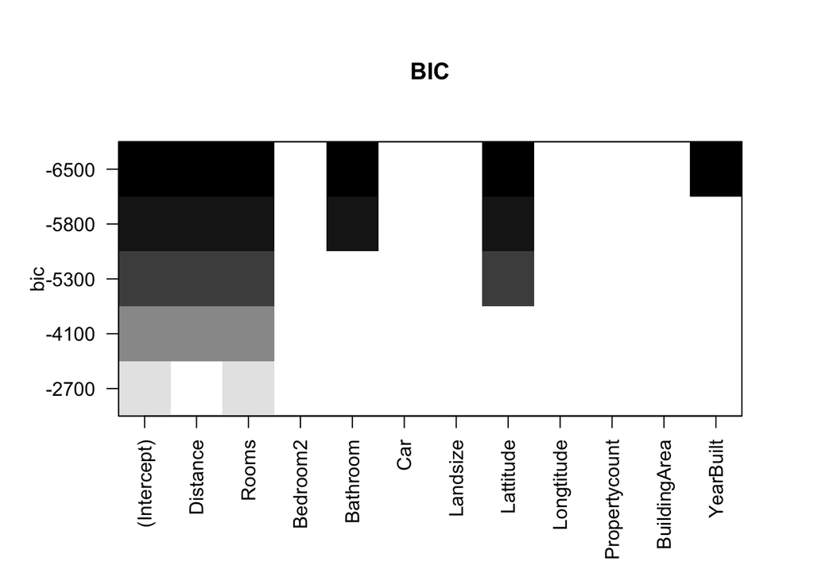

# 3 Regularization: Lasso regression

## 3.1 Lasso Model

Regularization is to reduce the complexity of the model by adjusting the model parameters (number and size) to achieve the effect of avoiding overfitting. The most basic regularization method is to add a penalty term to the original target (cost) function to punish the model with high complexity. The regression problem is a process of function fitting. We hope that the model should not be too complicated, otherwise it is prone to overfitting. So we need to add a regularization term, and different regularization terms produce different regression methods. Lasso adds an L1 regularization term. L1 regularization can generate a sparse weight matrix, that is, a sparse model can be used for feature selection. To a certain extent, L1 can also prevent overfitting (Tibshirani, R. 1996).

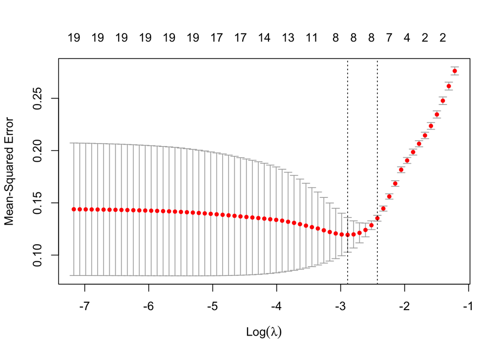

From the coefficient of lasso regression model, the variables of `Rooms`, `Type`, `Distance`, `Postcode`, `Bathroom`, `YearBuilt`, `Lattitude`, and `Longtitude` are related with response variable `Price`.